# lending_club_docker

```python
import numpy as np
import pandas as pd
from sklearn import preprocessing
import zipfile
import os
from collections import defaultdict
import datetime as dt
from sklearn.ensemble import RandomForestClassifier
from sklearn.model_selection import train_test_split
from sklearn.metrics import classification_report
from sklearn.model_selection import cross_val_score
from sklearn.model_selection import GridSearchCV
import sklearn.metrics as metrics
import matplotlib.pyplot as plt
```

```python
pd.set_option("display.max_rows", 1000)
pd.set_option("display.max_colwidth", 1000)
pd.set_option("display.max_columns", 1000)
```

## Loading the data

```python
path = 'D:\Downloads'
```

```python
z = zipfile.ZipFile('%s/lending-club-loan-data.zip' %path)
z.namelist()
```

```
['LCDataDictionary.xlsx', 'database.sqlite', 'loan.csv']
```

```python
df = pd.read_csv(z.open('loan.csv'), low_memory=False)
```

## Data exploration

#### Let's take a look at the data

```python
df.head(1)
```

|  | id | member_id | loan_amnt | funded_amnt | funded_amnt_inv | term | int_rate | installment | grade | sub_grade | emp_title | emp_length | home_ownership | annual_inc | verification_status | issue_d | loan_status | pymnt_plan | url | desc | purpose | title | zip_code | addr_state | dti | delinq_2yrs | earliest_cr_line | inq_last_6mths | mths_since_last_delinq | … |
| --- | --- | --- | --- | --- | --- | --- | --- | --- | --- | --- | --- | --- | --- | --- | --- | --- | --- | --- | --- | --- | --- | --- | --- | --- | --- | --- | --- | --- | --- | --- |
| 0 | 1077501 | 1296599 | 5000.0 | 5000.0 | 4975.0 | 36 months | 10.65 | 162.87 | B | B2 | NaN | 10+ years | RENT | 24000.0 | Verified | Dec-2011 | Fully Paid | n | https://www.lendingclub.com/browse/loanDetail.action?loan_id=1077501 | Borrower added on 12/22/11 > I need to upgrade my business technologies.<br> | credit_card | Computer | 860xx | AZ | 27.65 | 0.0 | Jan-1985 | 1.0 | NaN | … |

```python
df_dict = pd.read_excel(z.open('LCDataDictionary.xlsx'))
df_dict.sort_values('LoanStatNew')
```

|  | LoanStatNew | Description |
| --- | --- | --- |
| 75 | acc_now_delinq | The number of accounts on which the borrower is now delinquent. |
| 0 | addr_state | The state provided by the borrower in the loan application |
| 70 | all_util | Balance to credit limit on all trades |
| 1 | annual_inc | The self-reported annual income provided by the borrower during registration. |
| 2 | annual_inc_joint | The combined self-reported annual income provided by the co-borrowers during registration |
| 3 | application_type | Indicates whether the loan is an individual application or a joint application with two co-borrowers |
| 4 | collection_recovery_fee | post charge off collection fee |
| 5 | collections_12_mths_ex_med | Number of collections in 12 months excluding medical collections |
| 6 | delinq_2yrs | The number of 30+ days past-due incidences of delinquency in the borrower's credit file for the past 2 years |
| 7 | desc | Loan description provided by the borrower |
| 8 | dti | A ratio calculated using the borrower’s total monthly debt payments on the total debt obligations, excluding mortgage and the requested LC loan, divided by the borrower’s self-reported monthly income. |
| 9 | dti_joint | A ratio calculated using the co-borrowers' total monthly payments on the total debt obligations, excluding mortgages and the requested LC loan, divided by the co-borrowers' combined self-reported mont… |
| 10 | earliest_cr_line | The month the borrower's earliest reported credit line was opened |
| 11 | emp_length | Employment length in years. Possible values are between 0 and 10 where 0 means less than one year and 10 means ten or more years. |
| 12 | emp_title | The job title supplied by the Borrower when applying for the loan.* |
| 13 | fico_range_high | The upper boundary range the borrower’s FICO at loan origination belongs to. |
| 14 | fico_range_low | The lower boundary range the borrower’s FICO at loan origination belongs to. |
| 15 | funded_amnt | The total amount committed to that loan at that point in time. |
| 16 | funded_amnt_inv | The total amount committed by investors for that loan at that point in time. |
| 17 | grade | LC assigned loan grade |
| 18 | home_ownership | The home ownership status provided by the borrower during registration. Our values are: RENT, OWN, MORTGAGE, OTHER. |
| 19 | id | A unique LC assigned ID for the loan listing. |
| 66 | il_util | Ratio of total current balance to high credit/credit limit on all install acct |
| 20 | initial_list_status | The initial listing status of the loan. Possible values are – W, F |
| 72 | inq_fi | Number of personal finance inquiries |
| 74 | inq_last_12m | Number of credit inquiries in past 12 months |
| 21 | inq_last_6mths | The number of inquiries in past 6 months (excluding auto and mortgage inquiries) |
| 22 | installment | The monthly payment owed by the borrower if the loan originates. |
| 23 | int_rate | Interest Rate on the loan |
| 24 | is_inc_v | Indicates if income was verified by LC, not verified, or if the income source was verified |
| 25 | issue_d | The month which the loan was funded |
| 26 | last_credit_pull_d | The most recent month LC pulled credit for this loan |
| 27 | last_fico_range_high | The upper boundary range the borrower’s last FICO pulled belongs to. |
| 28 | last_fico_range_low | The lower boundary range the borrower’s last FICO pulled belongs to. |
| 29 | last_pymnt_amnt | Last total payment amount received |
| 30 | last_pymnt_d | Last month payment was received |
| 31 | loan_amnt | The listed amount of the loan applied for by the borrower. If at some point in time, the credit department reduces the loan amount, then it will be reflected in this value. |
| 32 | loan_status | Current status of the loan |
| 69 | max_bal_bc | Maximum current balance owed on all revolving accounts |
| 33 | member_id | A unique LC assigned Id for the borrower member. |
| 34 | mths_since_last_delinq | The number of months since the borrower's last delinquency. |
| 35 | mths_since_last_major_derog | Months since most recent 90-day or worse rating |
| 36 | mths_since_last_record | The number of months since the last public record. |
| 64 | mths_since_rcnt_il | Months since most recent installment accounts opened |
| 37 | next_pymnt_d | Next scheduled payment date |
| 38 | open_acc | The number of open credit lines in the borrower's credit file. |
| 60 | open_acc_6m | Number of open trades in last 6 months |
| 62 | open_il_12m | Number of installment accounts opened in past 12 months |
| 63 | open_il_24m | Number of installment accounts opened in past 24 months |
| 61 | open_il_6m | Number of currently active installment trades |
| 67 | open_rv_12m | Number of revolving trades opened in past 12 months |
| 68 | open_rv_24m | Number of revolving trades opened in past 24 months |
| 39 | out_prncp | Remaining outstanding principal for total amount funded |
| 40 | out_prncp_inv | Remaining outstanding principal for portion of total amount funded by investors |
| 41 | policy_code | publicly available policy_code=1\nnew products not publicly available policy_code=2 |
| 42 | pub_rec | Number of derogatory public records |
| 43 | purpose | A category provided by the borrower for the loan request. |
| 44 | pymnt_plan | Indicates if a payment plan has been put in place for the loan |
| 45 | recoveries | post charge off gross recovery |
| 46 | revol_bal | Total credit revolving balance |
| 47 | revol_util | Revolving line utilization rate, or the amount of credit the borrower is using relative to all available revolving credit. |
| 48 | sub_grade | LC assigned loan subgrade |
| 49 | term | The number of payments on the loan. Values are in months and can be either 36 or 60. |
| 50 | title | The loan title provided by the borrower |
| 76 | tot_coll_amt | Total collection amounts ever owed |
| 77 | tot_cur_bal | Total current balance of all accounts |
| 51 | total_acc | The total number of credit lines currently in the borrower's credit file |
| 65 | total_bal_il | Total current balance of all installment accounts |
| 73 | total_cu_tl | Number of finance trades |
| 52 | total_pymnt | Payments received to date for total amount funded |
| 53 | total_pymnt_inv | Payments received to date for portion of total amount funded by investors |
| 54 | total_rec_int | Interest received to date |
| 55 | total_rec_late_fee | Late fees received to date |
| 56 | total_rec_prncp | Principal received to date |
| 71 | total_rev_hi_lim | Total revolving high credit/credit limit |
| 57 | url | URL for the LC page with listing data. |
| 58 | verified_status_joint | Indicates if the co-borrowers' joint income was verified by LC, not verified, or if the income source was verified |
| 59 | zip_code | The first 3 numbers of the zip code provided by the borrower in the loan application. |
| 78 | NaN | NaN |
| 79 | NaN | * Employer Title replaces Employer Name for all loans listed after 9/23/2013 |

##### From a short inspection we can identify some columns that will likely be important to us, such as loan_amnt/funded_amnt, loan_status, int_rate (interest rate) and total_pymnt

##### Now let's better understand the size of the data we are working with:

```python
df.shape
```

```
(887379, 74)
```

##### and just to make sure, let's check that all loans are unique:

```python
df.drop_duplicates('id').shape
```

```
(887379, 74)
```

##### Some of the columns have some null values

```python
df.count().sort_values()
```

```
dti_joint                         509
verification_status_joint         511
annual_inc_joint                  511
il_util                         18617
mths_since_rcnt_il              20810
open_acc_6m                     21372
open_il_6m                      21372
open_il_12m                     21372
open_il_24m                     21372
inq_last_12m                    21372
total_bal_il                    21372
open_rv_12m                     21372
open_rv_24m                     21372
max_bal_bc                      21372
all_util                        21372
inq_fi                          21372
total_cu_tl                     21372
desc                           126029
mths_since_last_record         137053
mths_since_last_major_derog    221703
mths_since_last_delinq         433067
next_pymnt_d                   634408
tot_cur_bal                    817103
total_rev_hi_lim               817103
tot_coll_amt                   817103
emp_title                      835922
last_pymnt_d                   869720
revol_util                     886877
title                          887228
collections_12_mths_ex_med     887234
last_credit_pull_d             887326
earliest_cr_line               887350
open_acc                       887350
pub_rec                        887350
delinq_2yrs                    887350
total_acc                      887350
acc_now_delinq                 887350
inq_last_6mths                 887350
annual_inc                     887375
policy_code                    887379
```

[output cut: 20 more lines]

```
url                            887379
purpose                        887379
zip_code                       887379
addr_state                     887379
dti                            887379
revol_bal                      887379
initial_list_status            887379
out_prncp_inv                  887379
total_pymnt                    887379
total_pymnt_inv                887379
total_rec_prncp                887379
total_rec_int                  887379
recoveries                     887379
out_prncp                      887379
dtype: int64
```

##### We'll remove any column with less than 1000 non-null values, as it's very unlikely that they'll have any value.

##### We will probably end up removing columns with ~20k values, but let's leave them for now until we make sure they don't happen to be correlated to some interesting label

```python
to_drop = list(df.count()[df.count() < 1000].index)

df = df.drop(labels=to_drop, axis=1)
```

##### Let's see what types of status a loan can have

```python
df.loan_status.value_counts()
```

```
Current                                                601779
Fully Paid                                             207723
Charged Off                                             45248
Late (31-120 days)                                      11591
Issued                                                   8460
In Grace Period                                          6253
Late (16-30 days)                                        2357
Does not meet the credit policy. Status:Fully Paid       1988
Default                                                  1219
Does not meet the credit policy. Status:Charged Off       761
Name: loan_status, dtype: int64
```

##### At first glance one might consider defining a successful loan as one that was 'Fully Paid' and an unsuccessful loan one which was 'Charged Off' or late, and therefore make those statuses our training labels.

##### However, since our goal is not only to make a profit, but to make a decent one (let's say above 8% per year), we can focus on the actual amount received and compare it to the original loan amount, to see how much each loan would have made us.

##### It's important to note that many of the fully paid loans are 'safe' ones which have a very low return, and that even loans that were charged off can provide a profit:

```python
df['total_rcvd'] = df['total_pymnt'] + df['recoveries'] #After charge-off some money might be recovered
df['rcvd_pct'] = 100*(df['total_rcvd']/df['funded_amnt'] - 1)

df[df.loan_status == 'Charged Off'][df.rcvd_pct > 100][['loan_status',  'loan_amnt', 'total_rcvd', 'total_pymnt', 'recoveries', 'rcvd_pct']].sort_values('rcvd_pct', ascending=False).head(10)
```

|  | loan_status | loan_amnt | total_rcvd | total_pymnt | recoveries | rcvd_pct |
| --- | --- | --- | --- | --- | --- | --- |
| 183273 | Charged Off | 5700.0 | 14365.32 | 8057.55 | 6307.77 | 152.023158 |
| 249832 | Charged Off | 14400.0 | 35839.31 | 18260.17 | 17579.14 | 148.884097 |
| 886627 | Charged Off | 18000.0 | 43882.52 | 21941.26 | 21941.26 | 143.791778 |
| 67935 | Charged Off | 2000.0 | 4830.52 | 2415.26 | 2415.26 | 141.526000 |
| 227176 | Charged Off | 2100.0 | 4944.00 | 2472.00 | 2472.00 | 135.428571 |
| 99392 | Charged Off | 26000.0 | 59662.11 | 36626.19 | 23035.92 | 129.469654 |
| 49140 | Charged Off | 7350.0 | 16862.10 | 8558.36 | 8303.74 | 129.416327 |
| 202939 | Charged Off | 30000.0 | 68752.32 | 35232.05 | 33520.27 | 129.174400 |
| 209312 | Charged Off | 16000.0 | 36317.00 | 24008.57 | 12308.43 | 126.981250 |
| 14768 | Charged Off | 13750.0 | 30820.84 | 21748.69 | 9072.15 | 124.151564 |

##### Now we can use the actual received percentage to gauge how profitable a loan was

##### But knowing the total percentage is not enough, as we haven't taken into account the period of time we had to wait to receive the amount we loaned

```python
# df['actual_loan_years'] = ((pd.to_datetime(df['last_pymnt_d'])-pd.DateOffset(months = 1) - pd.to_datetime(df['issue_d'])).dt.days/365.0).round(2)

df['actual_loan_years'] = ((pd.to_datetime(df['last_pymnt_d']) - pd.to_datetime(df['issue_d'])).dt.days/365.0).round(2)
```

```python
df[df.rcvd_pct > 100][['loan_status',  'loan_amnt', 'total_rcvd', 'total_pymnt', 'recoveries', 'rcvd_pct', 'last_pymnt_d', 'issue_d', 'actual_loan_years']].sort_values('rcvd_pct', ascending=False).head(10)
```

|  | loan_status | loan_amnt | total_rcvd | total_pymnt | recoveries | rcvd_pct | last_pymnt_d | issue_d | actual_loan_years |
| --- | --- | --- | --- | --- | --- | --- | --- | --- | --- |
| 42191 | Does not meet the credit policy. Status:Charged Off | 25000.0 | 67223.92 | 39473.92 | 27750.00 | 168.895680 | Jan-2009 | Dec-2007 | 1.09 |
| 40518 | Does not meet the credit policy. Status:Charged Off | 8500.0 | 21714.16 | 11378.26 | 10335.90 | 155.460706 | Dec-2010 | Apr-2010 | 0.67 |
| 183273 | Charged Off | 5700.0 | 14365.32 | 8057.55 | 6307.77 | 152.023158 | Sep-2013 | Dec-2012 | 0.75 |
| 249832 | Charged Off | 14400.0 | 35839.31 | 18260.17 | 17579.14 | 148.884097 | Jan-2015 | Nov-2014 | 0.17 |
| 886627 | Charged Off | 18000.0 | 43882.52 | 21941.26 | 21941.26 | 143.791778 | NaN | Jan-2015 | NaN |
| 67935 | Charged Off | 2000.0 | 4830.52 | 2415.26 | 2415.26 | 141.526000 | NaN | Nov-2013 | NaN |
| 41840 | Does not meet the credit policy. Status:Charged Off | 6000.0 | 14297.54 | 7248.96 | 7048.58 | 138.292333 | Apr-2008 | Mar-2008 | 0.08 |
| 227176 | Charged Off | 2100.0 | 4944.00 | 2472.00 | 2472.00 | 135.428571 | NaN | Feb-2012 | NaN |
| 99392 | Charged Off | 26000.0 | 59662.11 | 36626.19 | 23035.92 | 129.469654 | Apr-2015 | Sep-2013 | 1.58 |
| 49140 | Charged Off | 7350.0 | 16862.10 | 8558.36 | 8303.74 | 129.416327 | Feb-2014 | Dec-2013 | 0.17 |

##### (not sure what's the meaning of a loan with a null or immediate charge-off date, so we might ignore those cases if we have enough without them)

##### We can now calculate the actual interest we would gain on the loan:

```python
df['actual_yearly_interest'] = df['rcvd_pct']/df['actual_loan_years']
```

```python
df[['grade', 'loan_status', 'loan_amnt', 'total_rcvd', 'rcvd_pct', 'int_rate', 'actual_yearly_interest',
        'term', 'actual_loan_years']][df['rcvd_pct'] > 0].sort_values('actual_yearly_interest', ascending=False).head(10)
```

|  | grade | loan_status | loan_amnt | total_rcvd | rcvd_pct | int_rate | actual_yearly_interest | term | actual_loan_years |
| --- | --- | --- | --- | --- | --- | --- | --- | --- | --- |
| 571624 | E | Fully Paid | 29400.0 | 29488.29 | 0.300306 | 20.99 | inf | 60 months | 0.0 |
| 737558 | D | Fully Paid | 13000.0 | 13039.46 | 0.303538 | 15.61 | inf | 60 months | 0.0 |
| 589382 | A | Fully Paid | 2500.0 | 2501.85 | 0.074000 | 5.32 | inf | 36 months | 0.0 |
| 528255 | C | Fully Paid | 10500.0 | 10505.23 | 0.049810 | 14.33 | inf | 60 months | 0.0 |
| 616699 | D | Fully Paid | 18950.0 | 18960.28 | 0.054248 | 15.61 | inf | 60 months | 0.0 |
| 616626 | C | Fully Paid | 7300.0 | 7335.14 | 0.481370 | 13.33 | inf | 36 months | 0.0 |
| 589564 | C | Fully Paid | 16800.0 | 16849.77 | 0.296250 | 13.33 | inf | 36 months | 0.0 |
| 725741 | C | Fully Paid | 6000.0 | 6017.26 | 0.287667 | 13.99 | inf | 36 months | 0.0 |
| 528169 | B | Fully Paid | 30000.0 | 30008.19 | 0.027300 | 8.18 | inf | 36 months | 0.0 |
| 684353 | D | Fully Paid | 25000.0 | 25124.03 | 0.496120 | 17.86 | inf | 60 months | 0.0 |

##### We run again into the issue of extremely short loan periods. It might be an interesting idea to target loans that are returned successfully and immediately, but as can be seen, while the ratio is great, the actual dollar gain for each loan is very low, so it might not be worth the risk - a single mistake causing us loss would offset our whole profit

```python
df[['grade', 'loan_status', 'loan_amnt', 'total_rcvd', 'total_pymnt', 'recoveries', 'rcvd_pct', 'int_rate', 'actual_yearly_interest',
        'term', 'actual_loan_years']][df['rcvd_pct'] > 0][df['actual_loan_years'] > 0] \
        .sort_values('actual_yearly_interest', ascending=False).head(10)
```

|  | grade | loan_status | loan_amnt | total_rcvd | total_pymnt | recoveries | rcvd_pct | int_rate | actual_yearly_interest | term | actual_loan_years |
| --- | --- | --- | --- | --- | --- | --- | --- | --- | --- | --- | --- |
| 41840 | D | Does not meet the credit policy. Status:Charged Off | 6000.0 | 14297.54 | 7248.96 | 7048.58 | 138.292333 | 12.61 | 1728.654167 | 36 months | 0.08 |
| 10743 | E | Charged Off | 11200.0 | 23924.30 | 12107.98 | 11816.32 | 113.609821 | 19.29 | 1420.122768 | 60 months | 0.08 |
| 424324 | D | Charged Off | 18000.0 | 38301.30 | 19380.42 | 18920.88 | 112.785000 | 18.25 | 1409.812500 | 60 months | 0.08 |
| 29595 | F | Charged Off | 3200.0 | 6772.35 | 3427.22 | 3345.13 | 111.635938 | 18.67 | 1395.449219 | 60 months | 0.08 |
| 281963 | A | Charged Off | 20000.0 | 41404.24 | 20902.10 | 20502.14 | 107.021200 | 8.39 | 1337.765000 | 60 months | 0.08 |
| 841916 | A | Charged Off | 4800.0 | 9845.48 | 4995.20 | 4850.28 | 105.114167 | 7.89 | 1313.927083 | 36 months | 0.08 |
| 203304 | E | Charged Off | 3000.0 | 5990.54 | 3051.23 | 2939.31 | 99.684667 | 20.49 | 1246.058333 | 36 months | 0.08 |
| 438767 | C | Charged Off | 5000.0 | 9943.72 | 5056.88 | 4886.84 | 98.874400 | 13.65 | 1235.930000 | 36 months | 0.08 |
| 249832 | D | Charged Off | 14400.0 | 35839.31 | 18260.17 | 17579.14 | 148.884097 | 15.99 | 875.788807 | 60 months | 0.17 |
| 49140 | C | Charged Off | 7350.0 | 16862.10 | 8558.36 | 8303.74 | 129.416327 | 14.98 | 761.272509 | 36 months | 0.17 |

##### We removed the loans with a problematic time period, but we now run into another strange phenomenon. The total received amount seems strangely large compared to the loan amount, and the recovered amount is also extremely similar to the total payed amount. There might be some issue with the data here, where the two amounts were not separated correctly and are in fact being counted twice.

##### For safety's sake, we'll backtrack a bit and change our measure to only take total_pymnt into account. In a 'normal' case, we would expect the recovery amount to be significantly lower, so we can hope that this does not cause us to miss too many interesting cases.

```python
df['total_rcvd'] = df['total_pymnt'] #+ df['recoveries']
df['rcvd_pct'] = 100*(df['total_rcvd']/df['loan_amnt'] - 1)

df['actual_yearly_interest'] = df['rcvd_pct']/df['actual_loan_years']
```

##### Now that we have defined a measure, we can split our data by its label, and investigate how its distributed among the different categories provided to us by Lending Club

```python
df[df.actual_yearly_interest >=8].shape[0]
```

```
141583
```

```python
half_year = [x/100.0 for x in range(0, 50, 8)]
years = [x for x in range(1, 6)]
bins = half_year + years
df['binned_loan_period'] = pd.cut(df.actual_loan_years, bins, right=False)
```

```python
df[df.actual_yearly_interest >=8]['binned_loan_period'].value_counts().sort_index()
```

```
[0.0, 0.08)      1122
[0.08, 0.16)     6145
[0.16, 0.24)     4890
[0.24, 0.32)     4993
[0.32, 0.4)      5253
[0.4, 0.48)      5258
[0.48, 1.0)     35680
[1.0, 2.0)      50787
[2.0, 3.0)      18301
[3.0, 4.0)       7885
[4.0, 5.0)        933
Name: binned_loan_period, dtype: int64
```

```python
df = df.drop('binned_loan_period', axis=1)
```

##### While not insignificant, cases with extremely short loan periods (less than 1 month) are not that numerous, so again, for safety's sake, we'll ignore them.

##### Now that we have a better definition of what constitutes a 'good' (i.e. profitable) case, we can finally add labels to our date

```python
df = df[df.actual_loan_years >= 0.08]

df['label'] = np.where(df.actual_yearly_interest >= 8, 1, 0)
```

##### We can use this new dataframe to investigate how our target loans differ in distribution compared to the rest

```python
g = df[df['label'] == 1].groupby('grade')['id'].count()
b = df[df['label'] == 0].groupby('grade')['id'].count()
grades = pd.DataFrame(dict(Good=g, Bad=b))
grades['good_ratio'] = grades.Good.div(grades.sum(axis=1))

grades
```

| grade | Bad | Good | good_ratio |
| --- | --- | --- | --- |
| A | 143071 | 2147 | 0.014785 |
| B | 207384 | 41606 | 0.167099 |
| C | 192848 | 47404 | 0.197309 |
| D | 106881 | 29925 | 0.218740 |
| E | 56034 | 13194 | 0.190588 |
| F | 17635 | 4920 | 0.218133 |
| G | 4112 | 1265 | 0.235261 |

```python
g = df[df['label'] == 1].groupby('loan_status')['id'].count()
b = df[df['label'] == 0].groupby('loan_status')['id'].count()
status = pd.DataFrame(dict(Good=g, Bad=b))
status['good_ratio'] = status.Good.div(status.sum(axis=1))

status
```

|  | Bad | Good | good_ratio |
| --- | --- | --- | --- |
| Charged Off | 44536 | 185.0 | 0.004137 |
| Current | 591782 | 1508.0 | 0.002542 |
| Default | 1202 | 8.0 | 0.006612 |
| Does not meet the credit policy. Status:Charged Off | 725 | 24.0 | 0.032043 |
| Does not meet the credit policy. Status:Fully Paid | 874 | 1114.0 | 0.560362 |
| Fully Paid | 69096 | 137498.0 | 0.665547 |
| In Grace Period | 5989 | 51.0 | 0.008444 |
| Issued | 48 | NaN | NaN |
| Late (16-30 days) | 2298 | 18.0 | 0.007772 |
| Late (31-120 days) | 11415 | 55.0 | 0.004795 |

##### We can now also deal with those columns we mentioned earlier which have relatively few values

```python
df.count().sort_values()
```

```
il_util                          5414
mths_since_rcnt_il               6023
open_il_24m                      6189
open_acc_6m                      6189
open_il_6m                       6189
inq_last_12m                     6189
total_cu_tl                      6189
inq_fi                           6189
all_util                         6189
max_bal_bc                       6189
open_il_12m                      6189
open_rv_24m                      6189
open_rv_12m                      6189
total_bal_il                     6189
desc                           125900
mths_since_last_record         133584
mths_since_last_major_derog    216206
mths_since_last_delinq         423231
next_pymnt_d                   617111
total_rev_hi_lim               798265
tot_cur_bal                    798265
tot_coll_amt                   798265
emp_title                      818286
revol_util                     867938
collections_12_mths_ex_med     868281
last_credit_pull_d             868374
total_acc                      868397
acc_now_delinq                 868397
pub_rec                        868397
open_acc                       868397
earliest_cr_line               868397
inq_last_6mths                 868397
delinq_2yrs                    868397
title                          868398
annual_inc                     868422
last_pymnt_amnt                868426
id                             868426
application_type               868426
last_pymnt_d                   868426
total_rcvd                     868426
```

[output cut: 22 more lines]

```
purpose                        868426
zip_code                       868426
addr_state                     868426
dti                            868426
revol_bal                      868426
initial_list_status            868426
out_prncp                      868426
actual_yearly_interest         868426
total_pymnt                    868426
total_pymnt_inv                868426
total_rec_prncp                868426
total_rec_int                  868426
pymnt_plan                     868426
label                          868426
dtype: int64
```

```python
low_vals = df.count()[df.count() < 25000].sort_values()
pd.DataFrame(dict(low_vals=low_vals, in_good=df[df['label'] == 1][list(low_vals.index)].count()))
```

|  | in_good | low_vals |
| --- | --- | --- |
| il_util | 28 | 5414 |
| mths_since_rcnt_il | 31 | 6023 |
| open_acc_6m | 33 | 6189 |
| open_il_6m | 33 | 6189 |
| open_il_12m | 33 | 6189 |
| open_il_24m | 33 | 6189 |
| total_bal_il | 33 | 6189 |
| open_rv_12m | 33 | 6189 |
| open_rv_24m | 33 | 6189 |
| max_bal_bc | 33 | 6189 |
| all_util | 33 | 6189 |
| inq_fi | 33 | 6189 |
| total_cu_tl | 33 | 6189 |
| inq_last_12m | 33 | 6189 |

##### And we see that we can indeed drop them safely

```python
df = df.drop(labels=list(low_vals.index), axis=1)
```

##### There remain various other columns to deal with, many of them of string (object) type. We'll have to figure out what we want to do with them

```python
df[list(df.dtypes[df.dtypes == 'object'].index)]
```

|  | term | grade | sub_grade | emp_title | emp_length | home_ownership | verification_status | issue_d | loan_status | pymnt_plan | url | desc | purpose | title | zip_code | addr_state | earliest_cr_line | initial_list_status | last_pymnt_d | next_pymnt_d | last_credit_pull_d | application_type |
| --- | --- | --- | --- | --- | --- | --- | --- | --- | --- | --- | --- | --- | --- | --- | --- | --- | --- | --- | --- | --- | --- | --- |
| 0 | 36 months | B | B2 | NaN | 10+ years | RENT | Verified | Dec-2011 | Fully Paid | n | https://www.lendingclub.com/browse/loanDetail.action?loan_id=1077501 | Borrower added on 12/22/11 > I need to upgrade my business technologies.<br> | credit_card | Computer | 860xx | AZ | Jan-1985 | f | Jan-2015 | NaN | Jan-2016 | INDIVIDUAL |
| 1 | 60 months | C | C4 | Ryder | < 1 year | RENT | Source Verified | Dec-2011 | Charged Off | n | https://www.lendingclub.com/browse/loanDetail.action?loan_id=1077430 | Borrower added on 12/22/11 > I plan to use this money to finance the motorcycle i am looking at. I plan to have it paid off as soon as possible/when i sell my old bike. I only need this money because … | car | bike | 309xx | GA | Apr-1999 | f | Apr-2013 | NaN | Sep-2013 | INDIVIDUAL |
| 2 | 36 months | C | C5 | NaN | 10+ years | RENT | Not Verified | Dec-2011 | Fully Paid | n | https://www.lendingclub.com/browse/loanDetail.action?loan_id=1077175 | NaN | small_business | real estate business | 606xx | IL | Nov-2001 | f | Jun-2014 | NaN | Jan-2016 | INDIVIDUAL |
| 3 | 36 months | C | C1 | AIR RESOURCES BOARD | 10+ years | RENT | Source Verified | Dec-2011 | Fully Paid | n | https://www.lendingclub.com/browse/loanDetail.action?loan_id=1076863 | Borrower added on 12/21/11 > to pay for property tax (borrow from friend, need to pay back) & central A/C need to be replace. I'm very sorry to let my loan expired last time.<br> | other | personel | 917xx | CA | Feb-1996 | f | Jan-2015 | NaN | Jan-2015 | INDIVIDUAL |
| 4 | 60 months | B | B5 | University Medical Group | 1 year | RENT | Source Verified | Dec-2011 | Current | n | https://www.lendingclub.com/browse/loanDetail.action?loan_id=1075358 | Borrower added on 12/21/11 > I plan on combining three large interest bills together and freeing up some extra each month to pay toward other bills. I've always been a good payor but have found myself… | other | Personal | 972xx | OR | Jan-1996 | f | Jan-2016 | Feb-2016 | Jan-2016 | INDIVIDUAL |
| 5 | 36 months | A | A4 | Veolia Transportaton | 3 years | RENT | Source Verified | Dec-2011 | Fully Paid | n | https://www.lendingclub.com/browse/loanDetail.action?loan_id=1075269 | NaN | wedding | My wedding loan I promise to pay back | 852xx | AZ | Nov-2004 | f | Jan-2015 | NaN | Sep-2015 | INDIVIDUAL |
| 6 | 60 months | C | C5 | Southern Star Photography | 8 years | RENT | Not Verified | Dec-2011 | Current | n | https://www.lendingclub.com/browse/loanDetail.action?loan_id=1069639 | Borrower added on 12/18/11 > I am planning on using the funds to pay off two retail credit cards with 24.99% interest rates, as well as a major bank credit card with a 18.99% rate. I pay all my bills … | debt_consolidation | Loan | 280xx | NC | Jul-2005 | f | Jan-2016 | Feb-2016 | Jan-2016 | INDIVIDUAL |
| 7 | 36 months | E | E1 | MKC Accounting | 9 years | RENT | Source Verified | Dec-2011 | Fully Paid | n | https://www.lendingclub.com/browse/loanDetail.action?loan_id=1072053 | Borrower added on 12/16/11 > Downpayment for a car.<br> | car | Car Downpayment | 900xx | CA | Jan-2007 | f | Jan-2015 | NaN | Dec-2014 | INDIVIDUAL |
| 8 | 60 months | F | F2 | NaN | 4 years | OWN | Source Verified | Dec-2011 | Charged Off | n | https://www.lendingclub.com/browse/loanDetail.action?loan_id=1071795 | Borrower added on 12/21/11 > I own a small home-based judgment collection business. I have 5 years experience collecting debts. I am now going from a home office to a small office. I also plan to buy … | small_business | Expand Business & Buy Debt Portfolio | 958xx | CA | Apr-2004 | f | Apr-2012 | NaN | Aug-2012 | INDIVIDUAL |
| 9 | 60 months | B | B5 | Starbucks | < 1 year | RENT | Verified | Dec-2011 | Charged Off | n | https://www.lendingclub.com/browse/loanDetail.action?loan_id=1071570 | Borrower added on 12/16/11 > I'm trying to build up my credit history. I live with my brother and have no car payment or credit cards. I am in community college and work full time. Im going to use the… | other | Building my credit history. | 774xx | TX | Sep-2004 | f | Nov-2012 | NaN | Mar-2013 | INDIVIDUAL |
| 10 | 60 months | C | C3 | Southwest Rural metro | 5 years | OWN | Not Verified | Dec-2011 | Fully Paid | n | https://www.lendingclub.com/browse/loanDetail.action?loan_id=1070078 | Borrower added on 12/15/11 > I had recived a loan from Citi Financial about a year ago, I was paying 29.99 intrest, so the refinance is to cut that rate since cleaning up my credit I have been paying … | debt_consolidation | High intrest Consolidation | 853xx | AZ | Jan-1998 | f | Jun-2013 | NaN | Dec-2015 | INDIVIDUAL |
| 11 | 36 months | B | B5 | UCLA | 10+ years | OWN | Source Verified | Dec-2011 | Fully Paid | n | https://www.lendingclub.com/browse/loanDetail.action?loan_id=1069908 | NaN | debt_consolidation | Consolidation | 913xx | CA | Oct-1989 | f | Sep-2013 | NaN | Aug-2013 | INDIVIDUAL |
| 12 | 36 months | C | C1 | Va. Dept of Conservation/Recreation | < 1 year | RENT | Source Verified | Dec-2011 | Charged Off | n | https://www.lendingclub.com/browse/loanDetail.action?loan_id=1064687 | Borrower added on 12/15/11 > Plan to pay off 2 charge accounts. I will close one of them and ask for a credit line decrease from the other. Also borrowed money from a friend and would like to pay that… | debt_consolidation | freedom | 245xx | VA | Apr-2004 | f | Jul-2012 | NaN | Nov-2012 | INDIVIDUAL |
| 13 | 36 months | B | B1 | Target | 3 years | RENT | Source Verified | Dec-2011 | Fully Paid | n | https://www.lendingclub.com/browse/loanDetail.action?loan_id=1069866 | Borrower added on 12/19/11 > I intend to pay this debt off within half the time allotted.Home-brewer investing in equipment, hopefully someday a brewpub owner with delicious beers to sell and locally … | credit_card | citicard fund | 606xx | IL | Jul-2003 | f | Jan-2015 | NaN | Jan-2016 | INDIVIDUAL |
| 14 | 36 months | B | B2 | SFMTA | 3 years | RENT | Source Verified | Dec-2011 | Charged Off | n | https://www.lendingclub.com/browse/loanDetail.action?loan_id=1069057 | NaN | other | Other Loan | 951xx | CA | May-1991 | f | Oct-2013 | NaN | Mar-2014 | INDIVIDUAL |
| 15 | 36 months | D | D1 | Internal revenue Service | < 1 year | RENT | Not Verified | Dec-2011 | Fully Paid | n | https://www.lendingclub.com/browse/loanDetail.action?loan_id=1069759 | NaN | debt_consolidation | Debt Consolidation Loan | 641xx | MO | Sep-2007 | f | Jan-2015 | NaN | Jan-2016 | INDIVIDUAL |
| 16 | 36 months | C | C4 | Chin's Restaurant | 4 years | RENT | Not Verified | Dec-2011 | Fully Paid | n | https://www.lendingclub.com/browse/loanDetail.action?loan_id=1065775 | NaN | home_improvement | Home | 921xx | CA | Oct-1998 | f | Jan-2015 | NaN | Apr-2015 | INDIVIDUAL |
| 17 | 36 months | A | A1 | Duracell | 10+ years | MORTGAGE | Not Verified | Dec-2011 | Fully Paid | n | https://www.lendingclub.com/browse/loanDetail.action?loan_id=1069971 | Borrower added on 12/15/11 > Payoff other lending club acct and pull out money for purchase<br><br> Borrower added on 12/15/11 > payoff current lending club account and take money for purchase<br> | major_purchase | Holiday | 067xx | CT | Aug-1993 | f | May-2013 | NaN | May-2014 | INDIVIDUAL |
| 18 | 36 months | B | B3 | Connection Inspection | 1 year | MORTGAGE | Verified | Dec-2011 | Fully Paid | n | https://www.lendingclub.com/browse/loanDetail.action?loan_id=1062474 | Borrower added on 12/16/11 > This is a loan i am really looking forward to it will help me and my whole family. thank you<br><br> Borrower added on 12/18/11 > This loan is for a medical procedure I've… | medical | Medical | 890xx | UT | Oct-2003 | f | Feb-2015 | NaN | Jul-2015 | INDIVIDUAL |
| 19 | 36 months | A | A1 | Network Interpreting Service | 6 years | RENT | Not Verified | Dec-2011 | Fully Paid | n | https://www.lendingclub.com/browse/loanDetail.action?loan_id=1069742 | NaN | debt_consolidation | lowerratemeanseasiertogetoutofdebt! | 921xx | CA | Jan-2001 | f | Jul-2012 | NaN | Jul-2012 | INDIVIDUAL |
| 20 | 60 months | C | C4 | Archdiocese of Galveston Houston | 3 years | RENT | Verified | Dec-2011 | Fully Paid | n | https://www.lendingclub.com/browse/loanDetail.action?loan_id=1069740 | After amassing credit card debt through several years of college, I now have spending under control and a stable job. With this loan I plan to pay off all the credit cards and close them down immediat… | debt_consolidation | Freedom From Credit Cards | 770xx | TX | Nov-1997 | f | Aug-2015 | NaN | Dec-2015 | INDIVIDUAL |
| 21 | 36 months | B | B4 | Osram Sylvania | 10+ years | RENT | Verified | Dec-2011 | Charged Off | n | https://www.lendingclub.com/browse/loanDetail.action?loan_id=1039153 | Borrower added on 12/16/11 > Decided to clean up the debt and get my finances together. Thank you for your consideration.<br> | debt_consolidation | Debt Cleanup | 335xx | FL | Feb-1983 | f | Sep-2013 | NaN | Jan-2016 | INDIVIDUAL |
| 22 | 36 months | B | B3 | Value Air | 10+ years | OWN | Source Verified | Dec-2011 | Fully Paid | n | https://www.lendingclub.com/browse/loanDetail.action?loan_id=1069710 | Borrower added on 12/17/11 > Have a stable job, will be absolutely no problem making monthly payments. Loan will be used to close high interest credit card accounts on which I've never had a late paym… | credit_card | Credit Card Loan | 799xx | TX | Jul-1985 | f | Jan-2015 | NaN | Jan-2016 | INDIVIDUAL |
| 23 | 36 months | B | B3 | Wells Fargo Bank | 5 years | RENT | Not Verified | Dec-2011 | Fully Paid | n | https://www.lendingclub.com/browse/loanDetail.action?loan_id=1069700 | NaN | debt_consolidation | Debt Consolidation | 917xx | CA | Apr-2003 | f | Oct-2013 | NaN | Mar-2014 | INDIVIDUAL |
| 24 | 36 months | B | B3 | bmg-educational | 1 year | RENT | Not Verified | Dec-2011 | Charged Off | n | https://www.lendingclub.com/browse/loanDetail.action?loan_id=1069559 | NaN | major_purchase | cash | 900xx | CA | Jun-2001 | f | Oct-2012 | NaN | Mar-2013 | INDIVIDUAL |
| 25 | 36 months | B | B1 | Winfield Pathology Consultants | 2 years | MORTGAGE | Verified | Dec-2011 | Fully Paid | n | https://www.lendingclub.com/browse/loanDetail.action?loan_id=1069697 | NaN | credit_card | No more credit card debt! | 605xx | IL | Feb-2002 | f | Sep-2012 | NaN | Sep-2012 | INDIVIDUAL |
| 27 | 60 months | D | D2 | Frito Lay | 2 years | RENT | Not Verified | Dec-2011 | Charged Off | n | https://www.lendingclub.com/browse/loanDetail.action?loan_id=1069657 | Borrower added on 12/16/11 > I have a stable job where I will never get laid off.<br><br> Borrower added on 12/16/11 > I need the loan to pay for some recent medical expenses and I need to get my car … | other | Other | 150xx | PA | Oct-2003 | f | Dec-2012 | NaN | May-2013 | INDIVIDUAL |
| 28 | 36 months | B | B3 | Shands Hospital at the University of Fl | 10+ years | MORTGAGE | Not Verified | Dec-2011 | Fully Paid | n | https://www.lendingclub.com/browse/loanDetail.action?loan_id=1069799 | NaN | debt_consolidation | Debt Consolidation | 326xx | FL | Aug-1984 | f | Apr-2013 | NaN | Jan-2016 | INDIVIDUAL |
| 29 | 36 months | B | B3 | Oakridge homes | < 1 year | RENT | Source Verified | Dec-2011 | Fully Paid | n | https://www.lendingclub.com/browse/loanDetail.action?loan_id=1047704 | Borrower added on 12/15/11 > My loan is for paying off my credit cards and being able to get a place to live since I live with my uncle at the moment and he needs me to leave. <br><br> Borrower added … | credit_card | Credit card repayment loan | 564xx | MN | Nov-2006 | f | Dec-2014 | NaN | Jan-2015 | INDIVIDUAL |
| 30 | 36 months | A | A3 | NaN | 7 years | MORTGAGE | Source Verified | Dec-2011 | Fully Paid | n | https://www.lendingclub.com/browse/loanDetail.action?loan_id=1032111 | Borrower added on 12/17/11 > This loan is a great opportunity and will help me gain better control over my finances. The convenience of one payment and one rate will help me save money and create bett… | debt_consolidation | Debt Consolidation | 141xx | NY | Dec-1987 | f | Jan-2015 | NaN | Dec-2014 | INDIVIDUAL |

[output cut: 971 more lines]

868426 rows × 22 columns

##### It is apparent that many of these are categorical and some might even be made ordinal after some manipulation. Columns that contain free text might have to be dropped.

##### The only one that can clearly be dropped is URL.

```python
df['url'].head(5)
```

```
0    https://www.lendingclub.com/browse/loanDetail.action?loan_id=1077501
1    https://www.lendingclub.com/browse/loanDetail.action?loan_id=1077430
2    https://www.lendingclub.com/browse/loanDetail.action?loan_id=1077175
3    https://www.lendingclub.com/browse/loanDetail.action?loan_id=1076863
4    https://www.lendingclub.com/browse/loanDetail.action?loan_id=1075358
Name: url, dtype: object
```

```python
df = df.drop('url', axis=1)
```

##### It might also be beneficial to see the number of unique values for each of these columns, as it might tell us whether the column is indeed binary or categorical (we'll treat a categorical column with too many categories as free text)

```python
unique_vals = df.nunique().sort_index().to_frame()
unique_vals['dtypes'] = df.dtypes.sort_index()
unique_vals.columns = ['unique_vals', 'data_types']

unique_vals = unique_vals.sort_values('unique_vals')
unique_vals
```

|  | unique_vals | data_types |
| --- | --- | --- |
| policy_code | 1 | float64 |
| label | 2 | int32 |
| initial_list_status | 2 | object |
| term | 2 | object |
| application_type | 2 | object |
| pymnt_plan | 2 | object |
| verification_status | 3 | object |
| home_ownership | 6 | object |
| grade | 7 | object |
| acc_now_delinq | 8 | float64 |
| loan_status | 10 | object |
| emp_length | 12 | object |
| collections_12_mths_ex_med | 12 | float64 |
| purpose | 14 | object |
| inq_last_6mths | 28 | float64 |
| delinq_2yrs | 29 | float64 |
| pub_rec | 31 | float64 |
| sub_grade | 35 | object |
| addr_state | 51 | object |
| open_acc | 76 | float64 |
| last_pymnt_d | 98 | object |
| next_pymnt_d | 100 | object |
| issue_d | 103 | object |
| last_credit_pull_d | 103 | object |
| actual_loan_years | 119 | float64 |
| mths_since_last_record | 123 | float64 |
| total_acc | 135 | float64 |
| mths_since_last_delinq | 155 | float64 |
| mths_since_last_major_derog | 167 | float64 |
| int_rate | 538 | float64 |
| earliest_cr_line | 697 | object |
| zip_code | 933 | object |
| revol_util | 1355 | float64 |
| funded_amnt | 1372 | float64 |
| loan_amnt | 1372 | float64 |
| dti | 4063 | float64 |
| total_rec_late_fee | 6181 | float64 |
| funded_amnt_inv | 9856 | float64 |
| tot_coll_amt | 10201 | float64 |
| collection_recovery_fee | 20482 | float64 |
| total_rev_hi_lim | 20963 | float64 |
| recoveries | 22745 | float64 |
| annual_inc | 48797 | float64 |
| title | 63078 | object |
| installment | 67980 | float64 |
| revol_bal | 73166 | float64 |
| desc | 124344 | object |
| last_pymnt_amnt | 231371 | float64 |
| out_prncp | 247424 | float64 |
| total_rec_prncp | 260196 | float64 |
| out_prncp_inv | 265304 | float64 |
| emp_title | 295265 | object |
| tot_cur_bal | 323740 | float64 |
| total_rec_int | 324299 | float64 |
| total_pymnt_inv | 505385 | float64 |
| total_pymnt | 505484 | float64 |
| total_rcvd | 505484 | float64 |
| rcvd_pct | 530526 | float64 |
| actual_yearly_interest | 560539 | float64 |
| id | 868426 | int64 |
| member_id | 868426 | int64 |

##### We can go ahead and remove the policy_code columns which only had one value, and 'binarize' columns with only 2 distinct valuesc

```python
unique_vals[unique_vals.unique_vals == 2].index
```

```
Index([u'label', u'initial_list_status', u'term', u'application_type',
       u'pymnt_plan'],
      dtype='object')
```

```python
df = df.drop('policy_code', axis=1)
```

```python
lb = preprocessing.LabelBinarizer()

cb = [col for col in unique_vals[unique_vals.unique_vals == 2].index if col!='label']

for c in cb:
    print c
    df[c] = lb.fit_transform(df[c])
```

```
initial_list_status
term
application_type
pymnt_plan
```

##### Let's take a look at the columns that we still need to deal with

```python
unique_vals[(unique_vals.unique_vals > 2)]
```

|  | unique_vals | data_types |
| --- | --- | --- |
| verification_status | 3 | object |
| home_ownership | 6 | object |
| grade | 7 | object |
| acc_now_delinq | 8 | float64 |
| loan_status | 10 | object |
| emp_length | 12 | object |
| collections_12_mths_ex_med | 12 | float64 |
| purpose | 14 | object |
| inq_last_6mths | 28 | float64 |
| delinq_2yrs | 29 | float64 |
| pub_rec | 31 | float64 |
| sub_grade | 35 | object |
| addr_state | 51 | object |
| open_acc | 76 | float64 |
| last_pymnt_d | 98 | object |
| next_pymnt_d | 100 | object |
| issue_d | 103 | object |
| last_credit_pull_d | 103 | object |
| actual_loan_years | 119 | float64 |
| mths_since_last_record | 123 | float64 |
| total_acc | 135 | float64 |
| mths_since_last_delinq | 155 | float64 |
| mths_since_last_major_derog | 167 | float64 |
| int_rate | 538 | float64 |
| earliest_cr_line | 697 | object |
| zip_code | 933 | object |
| revol_util | 1355 | float64 |
| funded_amnt | 1372 | float64 |
| loan_amnt | 1372 | float64 |
| dti | 4063 | float64 |
| total_rec_late_fee | 6181 | float64 |
| funded_amnt_inv | 9856 | float64 |
| tot_coll_amt | 10201 | float64 |
| collection_recovery_fee | 20482 | float64 |
| total_rev_hi_lim | 20963 | float64 |
| recoveries | 22745 | float64 |
| annual_inc | 48797 | float64 |
| title | 63078 | object |
| installment | 67980 | float64 |
| revol_bal | 73166 | float64 |
| desc | 124344 | object |
| last_pymnt_amnt | 231371 | float64 |
| out_prncp | 247424 | float64 |
| total_rec_prncp | 260196 | float64 |
| out_prncp_inv | 265304 | float64 |
| emp_title | 295265 | object |
| tot_cur_bal | 323740 | float64 |
| total_rec_int | 324299 | float64 |
| total_pymnt_inv | 505385 | float64 |
| total_pymnt | 505484 | float64 |
| total_rcvd | 505484 | float64 |
| rcvd_pct | 530526 | float64 |
| actual_yearly_interest | 560539 | float64 |
| id | 868426 | int64 |
| member_id | 868426 | int64 |

##### We'll leave numerical columns as they are and leave for later string columns with more than 50 distinct values. That leaves us with:

```python
unique_vals[(unique_vals.unique_vals < 50) & (unique_vals.unique_vals > 2) & (unique_vals.data_types == 'object')]
```

|  | unique_vals | data_types |
| --- | --- | --- |
| verification_status | 3 | object |
| home_ownership | 6 | object |
| grade | 7 | object |
| loan_status | 10 | object |
| emp_length | 12 | object |
| purpose | 14 | object |
| sub_grade | 35 | object |

##### Which are few enough that we can inspect specifically and try to find the best way to deal with

```python
df[unique_vals[(unique_vals.unique_vals < 50) & (unique_vals.unique_vals > 2) & (unique_vals.data_types == 'object')].index]
```

|  | verification_status | home_ownership | grade | loan_status | emp_length | purpose | sub_grade |
| --- | --- | --- | --- | --- | --- | --- | --- |
| 0 | Verified | RENT | B | Fully Paid | 10+ years | credit_card | B2 |
| 1 | Source Verified | RENT | C | Charged Off | < 1 year | car | C4 |
| 2 | Not Verified | RENT | C | Fully Paid | 10+ years | small_business | C5 |
| 3 | Source Verified | RENT | C | Fully Paid | 10+ years | other | C1 |
| 4 | Source Verified | RENT | B | Current | 1 year | other | B5 |
| 5 | Source Verified | RENT | A | Fully Paid | 3 years | wedding | A4 |
| 6 | Not Verified | RENT | C | Current | 8 years | debt_consolidation | C5 |
| 7 | Source Verified | RENT | E | Fully Paid | 9 years | car | E1 |
| 8 | Source Verified | OWN | F | Charged Off | 4 years | small_business | F2 |
| 9 | Verified | RENT | B | Charged Off | < 1 year | other | B5 |
| 10 | Not Verified | OWN | C | Fully Paid | 5 years | debt_consolidation | C3 |
| 11 | Source Verified | OWN | B | Fully Paid | 10+ years | debt_consolidation | B5 |
| 12 | Source Verified | RENT | C | Charged Off | < 1 year | debt_consolidation | C1 |
| 13 | Source Verified | RENT | B | Fully Paid | 3 years | credit_card | B1 |
| 14 | Source Verified | RENT | B | Charged Off | 3 years | other | B2 |
| 15 | Not Verified | RENT | D | Fully Paid | < 1 year | debt_consolidation | D1 |
| 16 | Not Verified | RENT | C | Fully Paid | 4 years | home_improvement | C4 |
| 17 | Not Verified | MORTGAGE | A | Fully Paid | 10+ years | major_purchase | A1 |
| 18 | Verified | MORTGAGE | B | Fully Paid | 1 year | medical | B3 |
| 19 | Not Verified | RENT | A | Fully Paid | 6 years | debt_consolidation | A1 |
| 20 | Verified | RENT | C | Fully Paid | 3 years | debt_consolidation | C4 |
| 21 | Verified | RENT | B | Charged Off | 10+ years | debt_consolidation | B4 |
| 22 | Source Verified | OWN | B | Fully Paid | 10+ years | credit_card | B3 |
| 23 | Not Verified | RENT | B | Fully Paid | 5 years | debt_consolidation | B3 |
| 24 | Not Verified | RENT | B | Charged Off | 1 year | major_purchase | B3 |
| 25 | Verified | MORTGAGE | B | Fully Paid | 2 years | credit_card | B1 |
| 27 | Not Verified | RENT | D | Charged Off | 2 years | other | D2 |
| 28 | Not Verified | MORTGAGE | B | Fully Paid | 10+ years | debt_consolidation | B3 |
| 29 | Source Verified | RENT | B | Fully Paid | < 1 year | credit_card | B3 |
| 30 | Source Verified | MORTGAGE | A | Fully Paid | 7 years | debt_consolidation | A3 |

[output cut: 971 more lines]

868426 rows × 7 columns

##### Most of these can safely be encoded as numerical categories, emp_length and sub_grade actually as ordinal categories. Grade we can probably drop, as its information is also encoded into sub_grade.

##### We should probably note that for the non-ordinal categorical features it might be better analytically to do a one-hot encoding, but as we intend to use tree based models in this case, which don't deal with OHE very well, we will stick to a simpler encoding

```python
df = df.drop('grade', axis=1)
unique_vals = unique_vals.drop('grade')
```

##### loan_status actually contains 'future' information that we shouldn't have while training, so we'll remove it and continue working with a dataframe, from which we'll remove all such columns

```python
df_future = df.copy() #we'll keep a copy in case we want to reference this later

df = df.drop('loan_status', axis=1)
unique_vals = unique_vals.drop('loan_status')
```

```python
df.emp_length = df.emp_length.str.replace('years', '').str.replace('year', '').str.replace('10\+', '11').str.replace('n/a', '0').str.replace('< 1', '0.5')
df.emp_length = df.emp_length.astype('float')
```

```python
#checkpoint
df2 = df.copy()
```

```python
for col in ['verification_status', 'home_ownership', 'purpose', 'sub_grade']:
    df[col] = df[col].sort_values().astype('category').cat.codes
```

##### We still haven't dealt with the higher cardinality string columns. We'll try a simple solution - either simplify them where there's an easy way to do so, or just remove them.

```python
high_cardinality = unique_vals[(unique_vals.unique_vals > 50) & (unique_vals.data_types == 'object')].index
unique_vals[(unique_vals.unique_vals > 50) & (unique_vals.data_types == 'object')]
```

|  | unique_vals | data_types |
| --- | --- | --- |
| addr_state | 51 | object |
| last_pymnt_d | 98 | object |
| next_pymnt_d | 100 | object |
| issue_d | 103 | object |
| last_credit_pull_d | 103 | object |
| earliest_cr_line | 697 | object |
| zip_code | 933 | object |
| title | 63078 | object |
| desc | 124344 | object |
| emp_title | 295265 | object |

##### last and next payment dates also refer to future info, so we'll remove them as well

```python
df = df.drop('next_pymnt_d', axis=1)
unique_vals = unique_vals.drop('next_pymnt_d')

df = df.drop('last_pymnt_d', axis=1)
unique_vals = unique_vals.drop('last_pymnt_d')

high_cardinality = unique_vals[(unique_vals.unique_vals > 50) & (unique_vals.data_types == 'object')].index
```

##### Let's see how these unique values are distirbuted in our data

```python
def apply_counts(df_col):
    vals = zip(df_col.value_counts().index, df_col.value_counts())
    nulls = list(np.zeros(df_col.shape[0] - len(vals)))
    return vals + nulls


df[high_cardinality].apply(apply_counts)
#     .apply(lambda x: apply_counts(x))
```

|  | addr_state | issue_d | last_credit_pull_d | earliest_cr_line | zip_code | title | desc | emp_title |
| --- | --- | --- | --- | --- | --- | --- | --- | --- |
| 0 | (CA, 126861) | (Oct-2015, 48472) | (Jan-2016, 713032) | (Aug-2001, 6534) | (945xx, 9557) | (Debt consolidation, 403500) | ( , 244) | (Teacher, 13083) |
| 1 | (NY, 72514) | (Jul-2015, 45781) | (Dec-2015, 18917) | (Aug-2000, 6436) | (750xx, 9218) | (Credit card refinancing, 159825) | (Debt Consolidation, 13) | (Manager, 10922) |
| 2 | (TX, 69571) | (Oct-2014, 38754) | (Nov-2015, 11359) | (Oct-2000, 6210) | (112xx, 9052) | (Home improvement, 39055) | ( Borrower added on 03/17/14 > Debt consolidation<br>, 11) | (Registered Nurse, 5380) |
| 3 | (FL, 59587) | (Nov-2015, 37364) | (Oct-2015, 10342) | (Oct-2001, 6022) | (606xx, 8462) | (Other, 30796) | ( Borrower added on 03/10/14 > Debt consolidation<br>, 10) | (RN, 5222) |
| 4 | (IL, 34782) | (Aug-2015, 35743) | (Sep-2015, 9994) | (Aug-2002, 5933) | (300xx, 7921) | (Debt Consolidation, 15752) | ( Borrower added on 02/19/14 > Debt consolidation<br>, 9) | (Owner, 5160) |
| 5 | (NJ, 32580) | (Apr-2015, 35338) | (Jul-2015, 8549) | (Sep-2000, 5811) | (100xx, 7480) | (Major purchase, 11617) | ( Borrower added on 01/29/14 > Debt consolidation<br>, 8) | (Supervisor, 4858) |
| 6 | (PA, 30761) | (Jan-2015, 35040) | (Aug-2015, 7873) | (Nov-1999, 5762) | (070xx, 7289) | (Business, 6489) | (Camping Membership, 8) | (Sales, 4096) |
| 7 | (OH, 29001) | (May-2015, 31824) | (Jun-2015, 7043) | (Oct-1999, 5739) | (331xx, 7245) | (Medical expenses, 6438) | ( Borrower added on 01/15/14 > Debt consolidation<br>, 7) | (Project Manager, 3885) |
| 8 | (GA, 28411) | (Jul-2014, 29293) | (Apr-2015, 6112) | (Nov-2000, 5712) | (900xx, 7140) | (Car financing, 5379) | ( Borrower added on 01/22/14 > Debt consolidation<br>, 7) | (Office Manager, 3450) |
| 9 | (VA, 25663) | (Sep-2015, 28513) | (May-2015, 5899) | (Sep-2002, 5681) | (770xx, 6760) | (Consolidation, 5378) | ( Borrower added on 02/19/14 > Debt Consolidation<br>, 6) | (Driver, 3448) |
| 10 | (NC, 24168) | (Jun-2015, 28364) | (Mar-2015, 5730) | (Oct-2002, 5568) | (891xx, 6295) | (debt consolidation, 4829) | ( Borrower added on 03/14/14 > Debt consolidation<br>, 6) | (General Manager, 3096) |
| 11 | (MI, 22474) | (Dec-2015, 27043) | (Jan-2015, 5236) | (Sep-2001, 5546) | (917xx, 6211) | (Debt Consolidation Loan, 3797) | ( Borrower added on 03/03/14 > Debt consolidation<br>, 6) | (Director, 3083) |
| 12 | (MD, 20574) | (Mar-2015, 25345) | (Feb-2015, 4992) | (Aug-1999, 5498) | (330xx, 6136) | (Moving and relocation, 3790) | ( Borrower added on 03/07/14 > Debt consolidation<br>, 6) | (manager, 3056) |
| 13 | (MA, 20162) | (Nov-2014, 25020) | (Dec-2014, 3684) | (Sep-1999, 5479) | (117xx, 6003) | (Vacation, 3685) | ( Borrower added on 01/06/14 > Debt consolidation<br>, 6) | (teacher, 2868) |
| 14 | (AZ, 19969) | (Feb-2015, 23727) | (Oct-2014, 3351) | (Sep-2003, 5467) | (104xx, 5882) | (Credit Card Consolidation, 2358) | ( Borrower added on 02/26/14 > Debt Consolidation<br>, 6) | (owner, 2743) |
| 15 | (WA, 19038) | (May-2014, 19089) | (Nov-2014, 3153) | (Jul-2001, 5238) | (921xx, 5547) | (Home buying, 2269) | ( Borrower added on 02/06/14 > Debt consolidation<br>, 6) | (Engineer, 2600) |
| 16 | (CO, 18440) | (Apr-2014, 19059) | (Sep-2014, 2956) | (Nov-2001, 5116) | (852xx, 5340) | (consolidation, 2172) | ( Borrower added on 02/03/14 > Debt consolidation<br>, 6) | (President, 2498) |
| 17 | (MN, 15627) | (Aug-2014, 18797) | (Aug-2014, 2800) | (Aug-2003, 5074) | (926xx, 5308) | (Personal Loan, 2129) | ( Borrower added on 01/03/14 > Debt consolidation<br>, 6) | (driver, 2356) |
| 18 | (MO, 13916) | (Jun-2014, 17169) | (Jul-2014, 2768) | (Oct-2003, 5073) | (913xx, 5060) | (Consolidation Loan, 1777) | ( Borrower added on 01/27/14 > Debt consolidation<br>, 6) | (Vice President, 2293) |
| 19 | (IN, 13485) | (Mar-2014, 16501) | (May-2014, 2281) | (Mar-2001, 5070) | (925xx, 4798) | (Home Improvement, 1769) | ( Borrower added on 07/25/13 > Debt consolidation<br>, 6) | (Attorney, 2084) |
| 20 | (CT, 13240) | (Jan-2014, 15619) | (Jun-2014, 2230) | (Sep-1998, 5062) | (113xx, 4717) | (Credit Card Refinance, 1466) | ( Borrower added on 03/05/14 > debt consolidation<br>, 6) | (Operations Manager, 2022) |
| 21 | (TN, 12581) | (Feb-2014, 15263) | (Mar-2014, 2197) | (Dec-2000, 4996) | (334xx, 4645) | (Credit Card Payoff, 1386) | ( Borrower added on 01/14/13 > Debt consolidation<br>, 6) | (Accountant, 1982) |
| 22 | (NV, 12163) | (Dec-2013, 15012) | (Apr-2014, 2189) | (May-2001, 4964) | (481xx, 4526) | (Consolidate, 1266) | ( Borrower added on 03/18/14 > Debt consolidation<br>, 6) | (Administrative Assistant, 1975) |
| 23 | (WI, 11331) | (Nov-2013, 14669) | (Feb-2014, 1921) | (Dec-2001, 4948) | (601xx, 4502) | (Personal, 1182) | ( Borrower added on 02/27/13 > Debt consolidation<br>, 5) | (Sales Manager, 1803) |
| 24 | (AL, 10957) | (Oct-2013, 14101) | (Jan-2014, 1786) | (Dec-1999, 4943) | (604xx, 4443) | (Loan, 1029) | (refinancing, 5) | (Account Manager, 1683) |
| 25 | (OR, 10689) | (Sep-2013, 12972) | (Feb-2013, 1437) | (Sep-2004, 4929) | (080xx, 4438) | (Freedom, 801) | ( Borrower added on 02/25/14 > Debt consolidation.<br>, 5) | (Police Officer, 1669) |
| 27 | (SC, 10414) | (Aug-2013, 12667) | (Nov-2013, 1405) | (Jul-2000, 4906) | (021xx, 4438) | (Credit Card Loan, 783) | ( Borrower added on 01/23/14 > Debt consolidation<br>, 5) | (sales, 1663) |
| 28 | (LA, 10359) | (Jul-2013, 11900) | (Dec-2013, 1386) | (Oct-1998, 4858) | (600xx, 4427) | (personal, 771) | ( Borrower added on 10/23/13 > Debt consolidation<br>, 5) | (supervisor, 1644) |
| 29 | (KY, 8374) | (Jun-2013, 10897) | (Oct-2013, 1269) | (Jun-2001, 4837) | (956xx, 4236) | (consolidate, 761) | ( Borrower added on 09/05/13 > Debt consolidation<br>, 5) | (Executive Assistant, 1567) |
| 30 | (OK, 7906) | (Sep-2014, 10597) | (Sep-2013, 1056) | (Mar-2000, 4816) | (920xx, 4197) | (personal loan, 742) | ( Borrower added on 12/13/13 > Debt consolidation<br>, 5) | (Analyst, 1491) |

[output cut: 971 more lines]

868426 rows × 8 columns

##### We see some interesting things here:

##### 1. Some features have most loans concentrated in very few values (title, last_credit_pull_d and addr_state)

##### 2. Other features like desc and emp_title seem to be free text and have too many different values for us to deal with in this manner

##### 3. issue_d, earliest_cr_line and zip_code seem pretty evenly spread out. One would expect issue_d to have no bearing on our problem, so we can drop it. The same might be said for earliest_cr_line, but it might indicate the age of the loan applicant; for it and for zip_code we'll see whether any of these values are correlated with profitability

```python
def just_counts(df_col):
    vals = list(df_col.value_counts().values)
    nulls = list(np.zeros(df_col.shape[0] - len(vals)))
    return vals + nulls

pd.DataFrame(df[df.label == 1][['earliest_cr_line', 'zip_code']].apply(just_counts).values/df[['earliest_cr_line', 'zip_code']].apply(just_counts).head(140461).values, columns=['earliest_cr_line', 'zip_code'])
```

|  | earliest_cr_line | zip_code |
| --- | --- | --- |
| 0 | 0.173401 | 0.194622 |
| 1 | 0.170758 | 0.168258 |
| 2 | 0.175201 | 0.163389 |
| 3 | 0.178678 | 0.156346 |
| 4 | 0.180179 | 0.165888 |
| 5 | 0.180348 | 0.174332 |
| 6 | 0.175633 | 0.175607 |
| 7 | 0.174769 | 0.167702 |
| 8 | 0.171394 | 0.167087 |
| 9 | 0.171097 | 0.172485 |
| 10 | 0.174210 | 0.175854 |
| 11 | 0.172737 | 0.171792 |
| 12 | 0.171881 | 0.166232 |
| 13 | 0.171929 | 0.169748 |
| 14 | 0.168465 | 0.170180 |
| 15 | 0.175067 | 0.173427 |
| 16 | 0.178460 | 0.178839 |
| 17 | 0.179543 | 0.178598 |
| 18 | 0.179184 | 0.179051 |
| 19 | 0.178107 | 0.186536 |
| 20 | 0.176215 | 0.182955 |
| 21 | 0.177142 | 0.176964 |
| 22 | 0.176269 | 0.178303 |
| 23 | 0.176031 | 0.175255 |
| 24 | 0.175400 | 0.176457 |
| 25 | 0.175492 | 0.173727 |
| 26 | 0.175296 | 0.172600 |
| 27 | 0.176616 | 0.166478 |
| 28 | 0.176556 | 0.173277 |
| 29 | 0.172965 | 0.172028 |

[output cut: 971 more lines]

140461 rows × 2 columns

##### They seem to be quite evenly distributed, so let's drop all 3

```python
for col in ['earliest_cr_line', 'zip_code', 'issue_d']:
    df = df.drop(col, axis=1)
    unique_vals = unique_vals.drop(col)
```

```python
df['title'] = df['title'].where(df['title'].isin(df['title'].value_counts().index[:2]), 'other')
df['last_credit_pull_d'] = df['last_credit_pull_d'].where(df['last_credit_pull_d'].isin(df['last_credit_pull_d'].value_counts().index[:1]), 'other')
df['addr_state'] = df['addr_state'].where(df['addr_state'].isin(df['addr_state'].value_counts().index[:4]), 'other')
```

```python
df['title'] = df['title'].sort_values().astype('category').cat.codes
df['last_credit_pull_d'] = df['last_credit_pull_d'].sort_values().astype('category').cat.codes
df['addr_state'] = df['addr_state'].sort_values().astype('category').cat.codes
```

##### Given more time we could have taken meaning out of the free text in the desc and emp_title columns, but for now we'll be satisfied with removing them and substituting desc with its length

```python
df['desc_length'] = df['desc'].str.len()

for col in ['desc', 'emp_title']:
    df = df.drop(col, axis=1)
    unique_vals = unique_vals.drop(col)
```

##### There are a few additional columns that possibly contain future information about the loan. Let's remove as well them to be safe

```python
to_remove = ['collection_recovery_fee', 'collections_12_mths_ex_med', 'funded_amnt', 'funded_amnt_inv', 'next_pymnt_d', 'out_prncp', 'out_prncp_inv', 'pymnt_plan', 'recoveries', 'total_rec_int', 'total_rec_late_fee', 'total_rec_prncp', 'total_bal_il', 'il_util']

df = df[[col for col in df.columns if col not in to_remove]]
```

##### Training

```python
df_final = pd.concat([df[df.label == 1], (df[df.label == 0].sample(df[df.label == 1].shape[0]))])
```

```python
X = df_final[[x for x in df_final.columns if x not in ['id', 'member_id', 'grade', 'total_rcvd', 'rcvd_ratio', 'actual_loan_years', 'actual_yearly_interest', 'total_rec_prncp', 'total_rec_int', 'total_rec_late_fee', 'recoveries', 'rcvd_pct', 'last_pymnt_amnt', 'collection_recovery_fee', 'label', 'loan_status', 'total_pymnt', 'total_pymnt_inv']]].fillna(0).values
```

```python
y = df_final.label.fillna(0).values
```

```python
X_train, X_test, y_train, y_test = train_test_split(X, y, random_state=42)
```

```python
rf = RandomForestClassifier(n_estimators=200, min_samples_leaf=10)
```

```python
grid_param = {
    'min_samples_leaf': [5], #10, 50, 100],
    'min_samples_split': [10], #100, 200],
    'criterion': ['gini'] #, 'entropy']
}

gd_rf = GridSearchCV(estimator=rf,
                     param_grid=grid_param,
                     scoring='precision',
                     cv=3,
                     n_jobs=2)
```

```python
gd_rf.fit(X_train, y_train)
```

```
GridSearchCV(cv=3, error_score='raise',
       estimator=RandomForestClassifier(bootstrap=True, class_weight=None, criterion='gini',
            max_depth=None, max_features='auto', max_leaf_nodes=None,
            min_impurity_decrease=0.0, min_impurity_split=None,
            min_samples_leaf=10, min_samples_split=2,
            min_weight_fraction_leaf=0.0, n_estimators=200, n_jobs=1,
            oob_score=False, random_state=None, verbose=0,
            warm_start=False),
       fit_params=None, iid=True, n_jobs=2,
       param_grid={'min_samples_split': [10], 'criterion': ['gini'], 'min_samples_leaf': [5]},
       pre_dispatch='2*n_jobs', refit=True, return_train_score=True,
       scoring='precision', verbose=0)
```

```python
gd_rf.best_estimator_
```

```
RandomForestClassifier(bootstrap=True, class_weight=None, criterion='gini',
            max_depth=None, max_features='auto', max_leaf_nodes=None,
            min_impurity_decrease=0.0, min_impurity_split=None,
            min_samples_leaf=5, min_samples_split=10,
            min_weight_fraction_leaf=0.0, n_estimators=200, n_jobs=1,
            oob_score=False, random_state=None, verbose=0,
            warm_start=False)
```

```python
gd_rf.score(X_train, y_train)
```

```
0.91931542666983601
```

```python
y_pred = gd_rf.predict(X_test)
print(classification_report(y_test, y_pred, target_names=['0', '1']))
```

```
             precision    recall  f1-score   support

          0       0.81      0.84      0.83     35332
          1       0.83      0.80      0.82     34899

avg / total       0.82      0.82      0.82     70231
```

```python
sorted(zip(gd_rf.best_estimator_.feature_importances_, df[[x for x in df.columns if x not in ['id', 'member_id', 'grade', 'total_rcvd', 'rcvd_ratio', 'actual_loan_years', 'actual_yearly_interest', 'total_rec_prncp', 'total_rec_int', 'total_rec_late_fee', 'recoveries', 'rcvd_pct', 'last_pymnt_amnt', 'collection_recovery_fee', 'label', 'loan_status', 'total_pymnt', 'total_pymnt_inv']]].columns), reverse=True)
```

```
[(0.30882179781991803, 'last_credit_pull_d'),
 (0.12029673961854651, 'int_rate'),
 (0.085885990985909308, 'sub_grade'),
 (0.043255713455872966, 'title'),
 (0.037610337854898909, 'desc_length'),
 (0.035301565143935461, 'tot_cur_bal'),
 (0.033624232518707144, 'dti'),
 (0.031462790302886214, 'total_rev_hi_lim'),
 (0.028254062775645086, 'annual_inc'),
 (0.027681367261931565, 'revol_util'),
 (0.027256559745980898, 'installment'),
 (0.026256072537677966, 'revol_bal'),
 (0.024566480821645569, 'total_acc'),
 (0.023881810343966973, 'loan_amnt'),
 (0.017992274014316512, 'purpose'),
 (0.016075568262196572, 'open_acc'),
 (0.015447524687137061, 'initial_list_status'),
 (0.014212669375290039, 'mths_since_last_delinq'),
 (0.014114087654342314, 'emp_length'),
 (0.013152394566730034, 'term'),
 (0.012266312671886215, 'inq_last_6mths'),
 (0.007993882788044691, 'verification_status'),
 (0.007668524610056909, 'mths_since_last_major_derog'),
 (0.0074770238632830234, 'addr_state'),
 (0.0054134411344081475, 'mths_since_last_record'),
 (0.0050413749612547663, 'home_ownership'),
 (0.0040737937208533154, 'tot_coll_amt'),
 (0.0030652258310479197, 'delinq_2yrs'),
 (0.0018170145371777318, 'pub_rec'),
 (3.3366134452128967e-05, 'acc_now_delinq'),
 (0.0, 'application_type')]
```

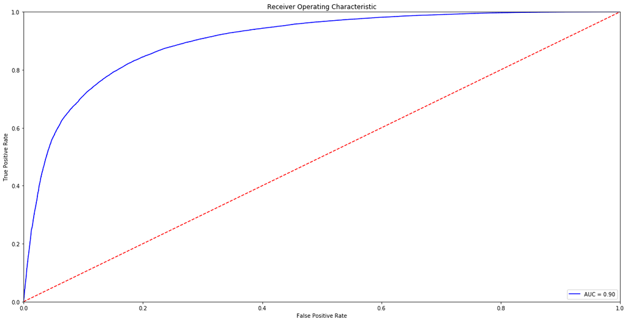

```python
%matplotlib inline
plt.rcParams['figure.figsize'] = [20, 10]

probs = gd_rf.predict_proba(X_test)
preds = probs[:,1]
fpr, tpr, threshold = metrics.roc_curve(y_test, preds, pos_label=1)
roc_auc = metrics.auc(fpr, tpr)

plt.title('Receiver Operating Characteristic')
plt.plot(fpr, tpr, 'b', label = 'AUC = %0.2f' % roc_auc)
plt.legend(loc = 'lower right')
plt.plot([0, 1], [0, 1],'r--')
plt.xlim([0, 1])
plt.ylim([0, 1])
plt.ylabel('True Positive Rate')
plt.xlabel('False Positive Rate')
plt.show()
```

```python
precision, recall, threshold = metrics.precision_recall_curve(y_test, preds, pos_label=1)

# precision

recall
```

```
array([  1.00000000e+00,   9.99971346e-01,   9.99971346e-01, ...,
         5.73082323e-05,   2.86541162e-05,   0.00000000e+00])
```

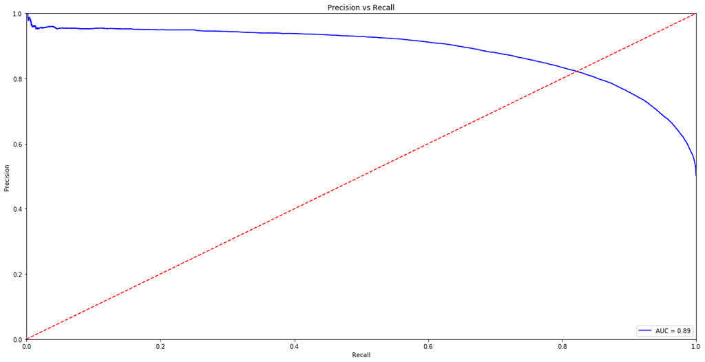

```python
precision, recall, threshold = metrics.precision_recall_curve(y_test, preds, pos_label=1)
roc_auc = metrics.auc(recall, precision)

plt.title('Precision vs Recall')
plt.plot(recall, precision, 'b', label = 'AUC = %0.2f' % roc_auc)
plt.legend(loc = 'lower right')
plt.plot([0, 1], [0, 1],'r--')
plt.xlim([0, 1])
plt.ylim([0, 1])
plt.ylabel('Precision')
plt.xlabel('Recall')
plt.show()
```